# Eugene R Users Meetup

February 13, 2018

## Welcome to RUG

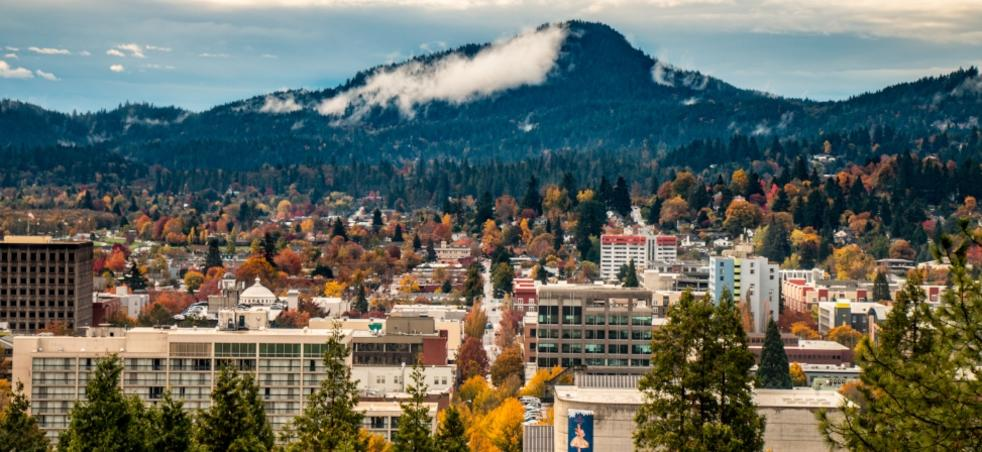

[figure not shown]

## Announcements

- Secured a vector level sponsorship from the RConsortium

[figure not shown]

- In communication with Cascadia`R` Conference for hosting 2019 or 2020

[figure not shown]

## R Community Code of Conduct

- **Open:** Members of the community are open to collaboration, whether it's on projects, working groups, packages, problems, or otherwise. We're receptive to constructive comment and criticism, as the experiences and skill sets of other members contribute to the whole of our efforts
- **Considerate:** Members of the community are considerate of their peers — other R users. We're thoughtful when addressing the efforts of others, keeping in mind that oftentimes the labor was completed simply for the good of the community.
- **Respectful:** Members of the community are respectful. We're respectful of others, their positions, their skills, their commitments, and their efforts.

Overall, we're good to each other. We contribute to this community not because we have to, but because we want to. If we remember that, these guidelines will come naturally.

*RUG is a safe place to ask for **help***

[figure not shown]

*RUG is a safe place to **fail** spectacularly!*

[figure not shown]

## RUG Goals

- Get involved
- Get connected
- Share experiences
- Contribute to the larger `R` community
- Advocate and advertise `R` in Eugene

## Staying relevant

[figure not shown]

## Sharing knowledge

[figure not shown]

## Meeting schedule:

- March 13th – Mixed Effect Modeling, Hannah Tavalire
- April 10th – Visualize Effect Sizes, Daniel Anderson
- May 8th – Tidy evaluation: how to use tidyverse tools inside your own functions, Charlotte Wickham
- June 2nd – Carpool to Cascadia R Conference (Portland)
- June 12th (tentative) – Cascadia Recap or possible slot for additional topic

## Topics for Future Meetings:

- Study groups learning established `R` curriculum
- Integration with
  - online survey tools (**Qualtrics**, REDCap, GoogleSurvey)
  - version control (Github)
- Shiny Developement
- Collection and analysis of
  - Twitter data
  - Timestamped location data (GPS, Strava)
- Please share your interests!!

## Ways to contribute:

- Assist with organization
- Lead a meetup/training/workshop
- Develope a logo/branding for Eugene `R` Users
- Inquire/Inform sponsorship opportunites (financial/in-kind)
- Encourage others to join
- Be your beautiful self

## We live in a beautiful place

Together we can enjoy the beauty of Oregon and `R`

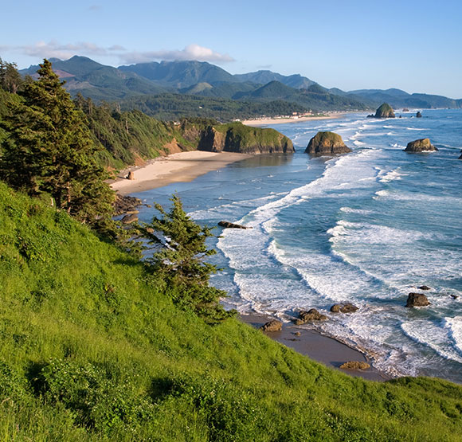

[figure not shown]

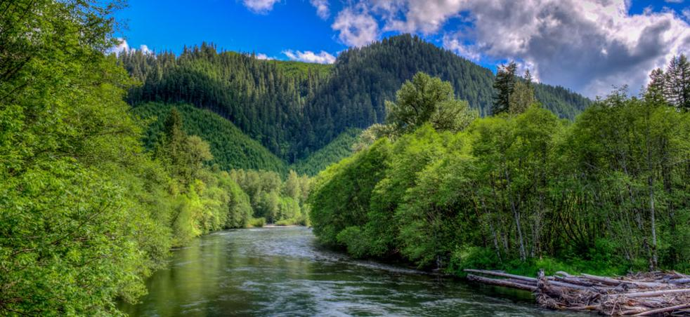

## Thank you

- Thank you to everyone who has contributed to and supported this group!

[figure not shown]

[figure not shown]

[figure not shown]

## Stay Connected

- Eugene `R` Users Resources
  - https://www.meetup.com/meetup-group-cwPiAlnB/
  - https://twitter.com/EugeneRUsers